# Categorising Countries

## Categorising Coutries

### Objective:

To categorise the countries using socio-economic and health factors that determine the overall development of the country.

### About organization:

HELP International is an international humanitarian NGO that is committed to fighting poverty and providing the people of backward countries with basic amenities and relief during the time of disasters and natural calamities.  
HELP International have been able to raise around $ 10 million. Now the CEO of the NGO needs to decide how to use this money strategically and effectively. So, CEO has to make decision to choose the countries that are in the direst need of aid. Hence, your Job as a Data scientist is to categorise the countries using some socio-economic and health factors that determine the overall development of the country. Then you need to suggest the countries which the CEO needs to focus on the most.

### About the Dataset:

**country**: Name of the country.  
**child_mort**: Death of children under 5 years of age per 1000 births.  
**exports**: Exports of goods and services per capita. Given as % of GDP per capita.  
**health**: Total health spending per capita. Given as %age of GDP per capita  
**imports**: Imports of goods and services per capita. Given as %age of the GDP per capita  
**Income**: Net income per person  
**Inflation**: The measurement of the annual growth rate of the Total GDP  
**life_expec**: The average number of years a new born child would live if the current mortality patterns are to remain the same  
**total_fer**: The number of children that would be born to each woman if the current age-fertility rates remain the same.  
**gdpp**: The GDP per capita. Calculated as the Total GDP divided by the total population.

**Source:** https://www.kaggle.com/rohan0301/unsupervised-learning-on-country-data

```python
import numpy as np
import matplotlib.pyplot as plt
import pandas as pd
import seaborn as sns
import warnings
warnings.simplefilter('ignore')
```

```python
df=pd.read_csv('Country-data.csv')
df.head()
```

|  | country | child_mort | exports | health | imports | income | inflation | life_expec | total_fer | gdpp |
| --- | --- | --- | --- | --- | --- | --- | --- | --- | --- | --- |
| 0 | Afghanistan | 90.2 | 10.0 | 7.58 | 44.9 | 1610 | 9.44 | 56.2 | 5.82 | 553 |
| 1 | Albania | 16.6 | 28.0 | 6.55 | 48.6 | 9930 | 4.49 | 76.3 | 1.65 | 4090 |
| 2 | Algeria | 27.3 | 38.4 | 4.17 | 31.4 | 12900 | 16.10 | 76.5 | 2.89 | 4460 |
| 3 | Angola | 119.0 | 62.3 | 2.85 | 42.9 | 5900 | 22.40 | 60.1 | 6.16 | 3530 |
| 4 | Antigua and Barbuda | 10.3 | 45.5 | 6.03 | 58.9 | 19100 | 1.44 | 76.8 | 2.13 | 12200 |

```python
print('Shape of the dataset:',df.shape)
```

```
Shape of the dataset: (167, 10)
```

### Exploratory Data Analysis

```python
print('Null Value Percentage:')
(df.isna().sum()/len(df))*100
```

```
Null Value Percentage:
```

```
country       0.0
child_mort    0.0
exports       0.0
health        0.0
imports       0.0
income        0.0
inflation     0.0
life_expec    0.0
total_fer     0.0
gdpp          0.0
dtype: float64
```

```python
df.describe()
```

|  | child_mort | exports | health | imports | income | inflation | life_expec | total_fer | gdpp |
| --- | --- | --- | --- | --- | --- | --- | --- | --- | --- |
| count | 167.000000 | 167.000000 | 167.000000 | 167.000000 | 167.000000 | 167.000000 | 167.000000 | 167.000000 | 167.000000 |
| mean | 38.270060 | 41.108976 | 6.815689 | 46.890215 | 17144.688623 | 7.781832 | 70.555689 | 2.947964 | 12964.155689 |
| std | 40.328931 | 27.412010 | 2.746837 | 24.209589 | 19278.067698 | 10.570704 | 8.893172 | 1.513848 | 18328.704809 |
| min | 2.600000 | 0.109000 | 1.810000 | 0.065900 | 609.000000 | -4.210000 | 32.100000 | 1.150000 | 231.000000 |
| 25% | 8.250000 | 23.800000 | 4.920000 | 30.200000 | 3355.000000 | 1.810000 | 65.300000 | 1.795000 | 1330.000000 |
| 50% | 19.300000 | 35.000000 | 6.320000 | 43.300000 | 9960.000000 | 5.390000 | 73.100000 | 2.410000 | 4660.000000 |
| 75% | 62.100000 | 51.350000 | 8.600000 | 58.750000 | 22800.000000 | 10.750000 | 76.800000 | 3.880000 | 14050.000000 |
| max | 208.000000 | 200.000000 | 17.900000 | 174.000000 | 125000.000000 | 104.000000 | 82.800000 | 7.490000 | 105000.000000 |

```python
print('Correlation Matrix:')
df.corr()
```

```
Correlation Matrix:
```

|  | child_mort | exports | health | imports | income | inflation | life_expec | total_fer | gdpp |
| --- | --- | --- | --- | --- | --- | --- | --- | --- | --- |
| child_mort | 1.000000 | -0.318093 | -0.200402 | -0.127211 | -0.524315 | 0.288276 | -0.886676 | 0.848478 | -0.483032 |
| exports | -0.318093 | 1.000000 | -0.114408 | 0.737381 | 0.516784 | -0.107294 | 0.316313 | -0.320011 | 0.418725 |
| health | -0.200402 | -0.114408 | 1.000000 | 0.095717 | 0.129579 | -0.255376 | 0.210692 | -0.196674 | 0.345966 |
| imports | -0.127211 | 0.737381 | 0.095717 | 1.000000 | 0.122406 | -0.246994 | 0.054391 | -0.159048 | 0.115498 |
| income | -0.524315 | 0.516784 | 0.129579 | 0.122406 | 1.000000 | -0.147756 | 0.611962 | -0.501840 | 0.895571 |
| inflation | 0.288276 | -0.107294 | -0.255376 | -0.246994 | -0.147756 | 1.000000 | -0.239705 | 0.316921 | -0.221631 |
| life_expec | -0.886676 | 0.316313 | 0.210692 | 0.054391 | 0.611962 | -0.239705 | 1.000000 | -0.760875 | 0.600089 |
| total_fer | 0.848478 | -0.320011 | -0.196674 | -0.159048 | -0.501840 | 0.316921 | -0.760875 | 1.000000 | -0.454910 |
| gdpp | -0.483032 | 0.418725 | 0.345966 | 0.115498 | 0.895571 | -0.221631 | 0.600089 | -0.454910 | 1.000000 |

```
Heatmap of the Correlation Matrix:
```

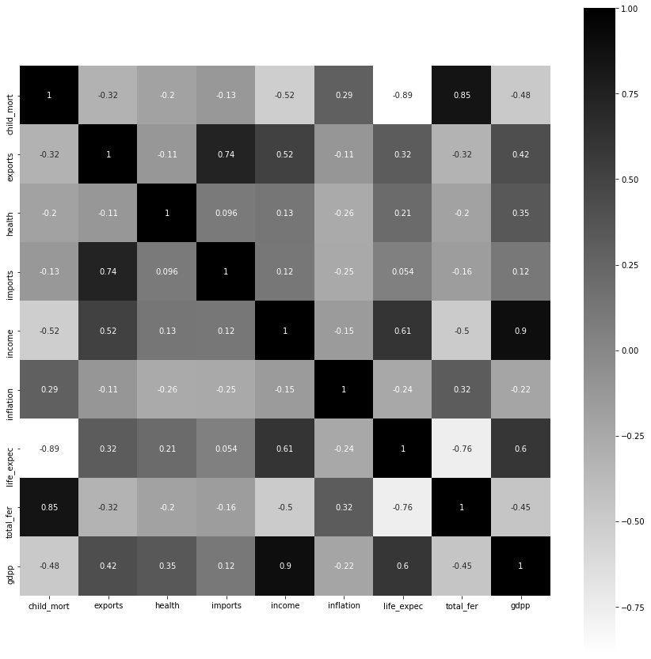

```python
print('Heatmap of the Correlation Matrix:')
plt.figure(figsize=(15,15))
sns.heatmap(df.corr(),square=True,annot=True,cmap='gray_r')
plt.show()
```

```
Some of the strong correlations:
```

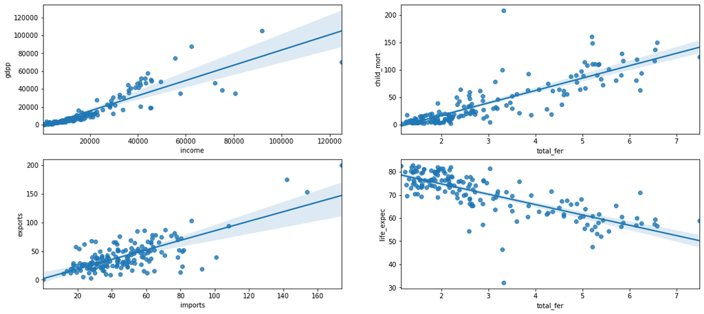

```python
fig,axes=plt.subplots(2,2,figsize=(18,8))
sns.regplot(x=df['income'],y=df['gdpp'],ax=axes[0][0])
sns.regplot(x=df['total_fer'],y=df['child_mort'],ax=axes[0][1])
sns.regplot(x=df['imports'],y=df['exports'],ax=axes[1][0])
sns.regplot(x=df['total_fer'],y=df['life_expec'],ax=axes[1][1])
print('Some of the strong correlations:')
plt.show()
```

###### Insights from heatmap:

- `Income` and `gddp` have the highest positive correlation in the whole dataset (0.9).
- `total_fer` and `child_mor` also have high positive correlation (0.85).
- `imports` and `exports` have positive correlation of magnitude about 0.74 which is also not bad.
- `life_expec` - `gddp`, `income` - `exports`, `income` - `life_expec` are also some of the pairs that have high positive correlation.
- Some of the high negative correlations include `life_expec` - `total_fer`, `income` - `child_mor`, `income` - `total_fer`

###### There are few strong correlations between the features of the dataset. This means that there are some redundant data in the dataset which explains same variance more than once.

### Principal Component Analysis

It is a technique to reduce the curse of dimensionality. We can also use this to capture the variance explained by the different features of the dataset in the form of principal components. This could be helpful in redundance of variance explained by many features. As we have many stongly correlated features in our dataset, we will carry out this and use these components for further processes.

Before we do PCA on our dataset we will standardise the data using zscores by applying standard scaler.

```python
from sklearn.preprocessing import StandardScaler
```

```python
x=StandardScaler().fit_transform(df.drop('country',1))
```

```python
from sklearn.decomposition import PCA
```

```python
pca=PCA()
pca.fit(x)
```

```
PCA(copy=True, iterated_power='auto', n_components=None, random_state=None,
    svd_solver='auto', tol=0.0, whiten=False)
```

```python
print('Ratio of variance explained by each principal component:')
print(pca.explained_variance_ratio_)
```

```
Ratio of variance explained by each principal component:
[0.4595174  0.17181626 0.13004259 0.11053162 0.07340211 0.02484235
 0.0126043  0.00981282 0.00743056]
```

```python
print('Cumulative explained variance ratio:')
print(np.cumsum(pca.explained_variance_ratio_))
```

```
Cumulative explained variance ratio:
[0.4595174  0.63133365 0.76137624 0.87190786 0.94530998 0.97015232
 0.98275663 0.99256944 1.        ]
```

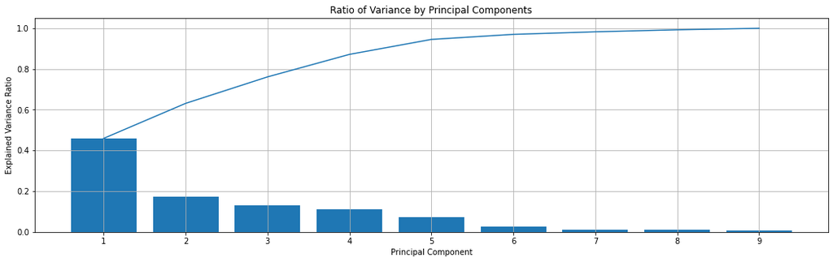

```python
plt.figure(figsize=(18,5))
plt.bar(np.arange(1,10),pca.explained_variance_ratio_)
plt.grid()
plt.title('Ratio of Variance by Principal Components')
plt.plot(np.arange(1,10),np.cumsum(pca.explained_variance_ratio_))
plt.xlabel('Principal Component')
plt.ylabel('Explained Variance Ratio')
plt.xticks(np.arange(1,10))
plt.show()
```

```python
print('Principal component vs Features of the Dataset:')
pd.DataFrame(index=df.drop('country',1).columns,data={'PC1':pca.components_[0],'PC2':pca.components_[1],
                                                'PC3':pca.components_[2],'PC4':pca.components_[3],
                                                'PC5':pca.components_[4],'PC6':pca.components_[5],
                                                'PC7':pca.components_[6],'PC8':pca.components_[7],
                                                'PC9':pca.components_[8]})
```

```
Principal component vs Features of the Dataset:
```

|  | PC1 | PC2 | PC3 | PC4 | PC5 | PC6 | PC7 | PC8 | PC9 |
| --- | --- | --- | --- | --- | --- | --- | --- | --- | --- |
| child_mort | -0.419519 | 0.192884 | -0.029544 | 0.370653 | -0.168970 | 0.200628 | -0.079489 | -0.682743 | 0.327542 |
| exports | 0.283897 | 0.613163 | 0.144761 | 0.003091 | 0.057616 | -0.059333 | -0.707303 | -0.014197 | -0.123082 |
| health | 0.150838 | -0.243087 | -0.596632 | 0.461897 | 0.518000 | 0.007276 | -0.249831 | 0.072497 | 0.113088 |
| imports | 0.161482 | 0.671821 | -0.299927 | -0.071907 | 0.255376 | -0.030032 | 0.592190 | -0.028946 | 0.099037 |
| income | 0.398441 | 0.022536 | 0.301548 | 0.392159 | -0.247150 | 0.160347 | 0.095562 | 0.352624 | 0.612982 |
| inflation | -0.193173 | -0.008404 | 0.642520 | 0.150442 | 0.714869 | 0.066285 | 0.104633 | -0.011538 | -0.025236 |
| life_expec | 0.425839 | -0.222707 | 0.113919 | -0.203797 | 0.108220 | -0.601127 | 0.018486 | -0.504664 | 0.294040 |
| total_fer | -0.403729 | 0.155233 | 0.019549 | 0.378304 | -0.135262 | -0.750689 | 0.028826 | 0.293353 | -0.026336 |
| gdpp | 0.392645 | -0.046022 | 0.122977 | 0.531995 | -0.180167 | 0.016779 | 0.242998 | -0.249696 | -0.625646 |

```python
xpca=pca.transform(x)
```

### KMeans

We will use KMeans Clustering technique to cluster the countries based on the features of our dataset. We will check elbow test and silhouette score to find the best number of clutsters.

```python
from sklearn.cluster import KMeans
```

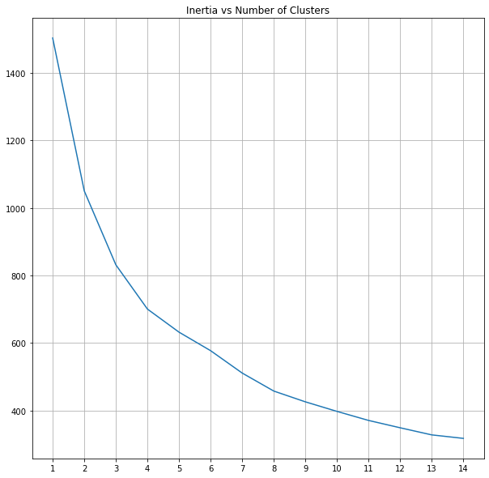

```python
inertia=[]
for i in range(1,15):
    km=KMeans(n_clusters=i,random_state=0)
    km.fit(xpca)
    inertia.append(km.inertia_)
plt.figure(figsize=(10,10))
plt.plot(np.arange(1,15),inertia)
plt.grid()
plt.xticks(np.arange(1,15))
plt.title('Inertia vs Number of Clusters')
plt.show()
```

n=3, 4 or 5 seems to be the optimal number of clusters by seeing the elbow plot. We will also check this using silhouette score.

```python
from sklearn.metrics import silhouette_score
```

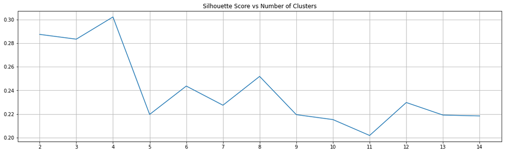

```python
sil_score=[]
for i in range(2,15):
    km=KMeans(n_clusters=i,random_state=0)
    km.fit(xpca)
    sil_score.append(silhouette_score(xpca,km.labels_))
plt.figure(figsize=(18,5))
plt.plot(np.arange(2,15),sil_score)
plt.grid()
plt.xticks(np.arange(2,15))
plt.title('Silhouette Score vs Number of Clusters')
plt.show()
```

No of clusters = 4 seems to be giving the highest silouette score and hence we will choose 4 as the number of clusters.

```python
km=KMeans(n_clusters=4)
km.fit(xpca)
```

```
KMeans(algorithm='auto', copy_x=True, init='k-means++', max_iter=300,
       n_clusters=4, n_init=10, n_jobs=None, precompute_distances='auto',
       random_state=None, tol=0.0001, verbose=0)
```

```python
df['kmlabels']=km.labels_
```

```
Distribution Variation in the features of the dataset  based on the clusters:
```

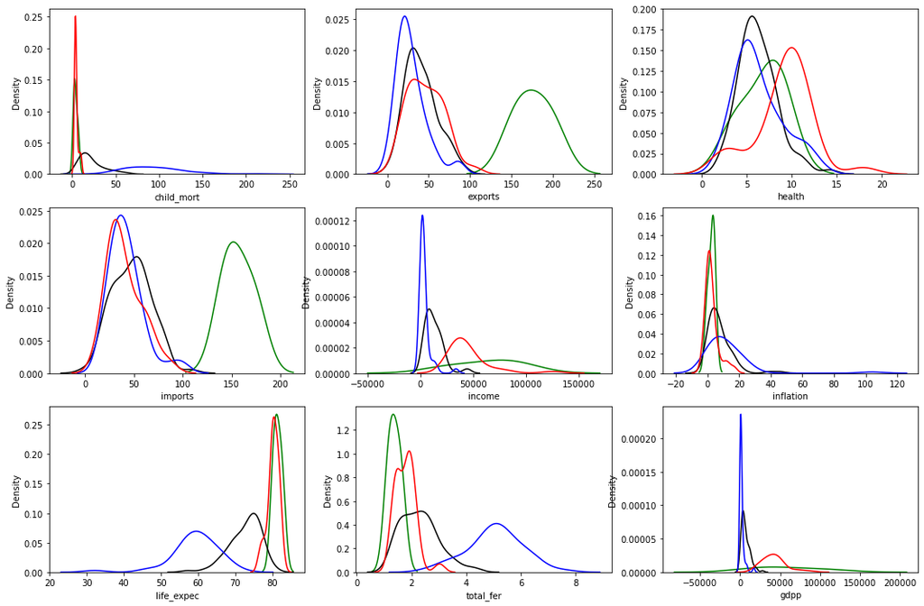

```python
fig,axes=plt.subplots(3,3,figsize=(18,12))
counter=0
col_list=list(df.columns[1:-1])
for i in range(3):
    for j in range(3):
        sns.distplot(df[df['kmlabels']==0][col_list[counter]],hist=False,ax=axes[i][j],color='green')
        sns.distplot(df[df['kmlabels']==1][col_list[counter]],hist=False,ax=axes[i][j],color='black')
        sns.distplot(df[df['kmlabels']==2][col_list[counter]],hist=False,ax=axes[i][j],color='blue')
        sns.distplot(df[df['kmlabels']==3][col_list[counter]],hist=False,ax=axes[i][j],color='red')
        counter+=1
print('Distribution Variation in the features of the dataset  based on the clusters:')
plt.show()
```

Visually, we can see that `total_fer` and `income` are two most significant distributions exhibiting variation among the 4 clusters.  
We could also try visualising the scatter plot of these two variables if that is significant.

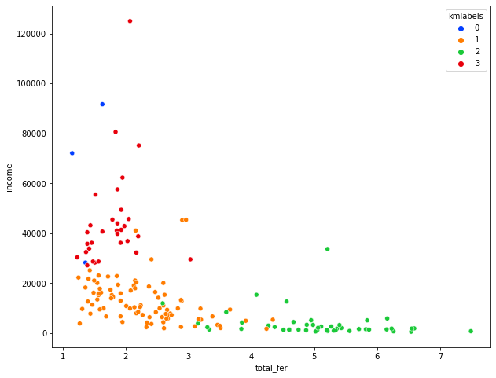

```python
plt.figure(figsize=(10,8))
sns.scatterplot(df['total_fer'],df['income'],hue=df['kmlabels'],palette='bright')
plt.show()
```

```python
print('Observing Centroids of all the km cluster lables:')
df.groupby('kmlabels').mean()
```

```
Observing Centroids of all the km cluster lables:
```

| kmlabels | child_mort | exports | health | imports | income | inflation | life_expec | total_fer | gdpp |
| --- | --- | --- | --- | --- | --- | --- | --- | --- | --- |
| 0 | 4.133333 | 176.000000 | 6.793333 | 156.666667 | 64033.333333 | 2.468000 | 81.433333 | 1.380000 | 57566.666667 |
| 1 | 21.954023 | 41.033207 | 6.240690 | 47.905355 | 12796.206897 | 7.532425 | 72.701149 | 2.302299 | 6764.505747 |
| 2 | 93.841304 | 28.837174 | 6.346957 | 42.128261 | 3738.978261 | 12.087065 | 59.232609 | 5.054348 | 1826.130435 |
| 3 | 4.903226 | 46.477419 | 9.127097 | 40.483871 | 44703.225806 | 2.607613 | 80.283871 | 1.786129 | 42574.193548 |

### Inferences:

**By observing the centroids, we could make certain inferences about the cluster labels:**

- Cluster 2 has the highest child mortality rate. Thes countries in the cluster 2 must be taken care of the children being born. Cluster 1 also has considerable high amount of child mortality rate.
- Cluster 0 has the highest export GDP percentage per capita and cluster 2 has the lowest.
- Health wise expenditure percentage from GDP per capita has been more or less equal in the clusters 0,1,2 but highest in the cluster 3.
- Imports GDP percentage per capita is highest in cluster 0 and more or less equal among all the other clusters.
- Net income per person is the highest in the cluster 0 countries and lowest in the cluster 2 countries.
- Inflation is being highest in the cluster 2 countries whereas the cluster 0 and cluster 3 have more or less same inflation average.
- Life expectancy has been the highest in the cluster 0 and cluster 3 countries whereas cluster 2 is lowest in life expectancy.
- Total fertility being the highest in cluster 2 and more or less in the same range in all other cluster countries.
- GDP per capita is lowest in the cluster 2 countries and highest in the cluster 0 countries.

### Key Recommendations:

```python
print('Top 15 countries to be considered first by the NGOs should be:')
print('Number of countries in the cluster 1:',len(df[df['kmlabels']==2]))
df[df['kmlabels']==2].sort_values(by=['child_mort','life_expec','gdpp'],ascending=[False,True,True])[['country','child_mort','life_expec','gdpp']].head(15)
```

[output not shown]

|  | country | child_mort | life_expec | gdpp |
| --- | --- | --- | --- | --- |
| 66 | Haiti | 208.0 | 32.1 | 662 |
| 132 | Sierra Leone | 160.0 | 55.0 | 399 |
| 32 | Chad | 150.0 | 56.5 | 897 |
| 31 | Central African Republic | 149.0 | 47.5 | 446 |
| 97 | Mali | 137.0 | 59.5 | 708 |
| 113 | Nigeria | 130.0 | 60.5 | 2330 |
| 112 | Niger | 123.0 | 58.8 | 348 |
| 3 | Angola | 119.0 | 60.1 | 3530 |
| 37 | Congo, Dem. Rep. | 116.0 | 57.5 | 334 |
| 25 | Burkina Faso | 116.0 | 57.9 | 575 |
| 64 | Guinea-Bissau | 114.0 | 55.6 | 547 |
| 40 | Cote d'Ivoire | 111.0 | 56.3 | 1220 |
| 49 | Equatorial Guinea | 111.0 | 60.9 | 17100 |
| 17 | Benin | 111.0 | 61.8 | 758 |
| 63 | Guinea | 109.0 | 58.0 | 648 |